# Huntington’s Disease Report

## What is Huntington’s Disease?

Huntington’s disease (HD) is a rare, inherited neurodegenerative disorder caused by a genetic mutation in the HTT gene. The mutation leads to an abnormal repetition of the CAG trinucleotide sequence, resulting in progressive brain cell damage. Symptoms of HD typically appear between the ages of 30 and 50 and include motor dysfunction, cognitive decline, and psychiatric disturbances.

[figure not shown]

## Research Keywords in Huntington’s Disease

There are many research studies in Huntington’s disease. Below is a visual representation of keywords scraped from scientific literature, showcasing the most discussed terms in this field.

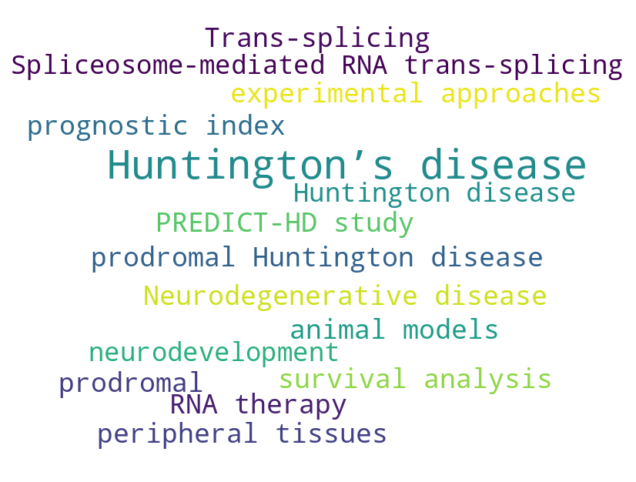

## Helping Patients with Decision-Making

One critical aspect of Huntington’s disease is helping patients make life decisions based on their genetic predisposition. Specifically, the number of CAG repeats in the HTT gene and the patient’s age are crucial in estimating the likelihood of disease onset and progression.

While research offers various models to predict outcomes, comparing different approaches is necessary to guide tailored interventions. For instance, there are two models in practical use for predicting HD progression: CAP (Zhang et al., 2011) and Langbehn model (Langbehn et al., 2004).

To demonstrate the similarities and differences between these two models, an interactive R Shiny app has been created for both statisticians and non-statisticians:

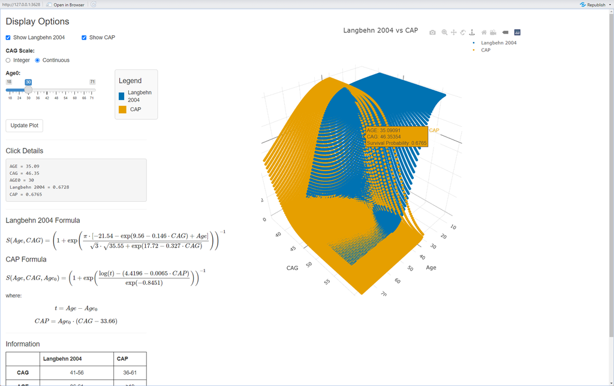

Shiny App Preview

👉 [Launch the HD Prediction App](https://dewei-lin.shinyapps.io/survival_compare/)

Stay tuned as we continue building tools and models to support HD patients and their families in navigating this challenging journey.

## References

- Langbehn DR, Brinkman RR, Falush D, Paulsen JS, Hayden MR, on behalf of the International Huntington’s Disease Collaborative Group. *A new model for prediction of the age of onset and penetrance for Huntington’s disease based on CAG length*. Clin Genet. 2004;65:267–277. [DOI](https://doi.org/10.1111/j.0009-9163.2004.00218.x)
- Zhang Y, Long JD, Mills JA, Warner JH, Lu W, Paulsen JS, and the PREDICT-HD Investigators and Coordinators of the Huntington Study Group. *Indexing Disease Progression at Study Entry With Individuals At-Risk for Huntington Disease.* 2011.